# Data Science Mini Project

Chia Yu Ying

5/5/2022

# 1 Load Libraries

Load the required libraries

```r
rm(list=ls())
library(datasets) # for iris data set
library(ggplot2) # for data visualization
library(dplyr)   # for data manipulation
library(geometry) # for dot product (euclidean distance)
```

# 2 Read Iris Data Set

```r
data(iris)
head(iris)
```

```
##   Sepal.Length Sepal.Width Petal.Length Petal.Width Species
## 1          5.1         3.5          1.4         0.2  setosa
## 2          4.9         3.0          1.4         0.2  setosa
## 3          4.7         3.2          1.3         0.2  setosa
## 4          4.6         3.1          1.5         0.2  setosa
## 5          5.0         3.6          1.4         0.2  setosa
## 6          5.4         3.9          1.7         0.4  setosa
```

# 3 Accessing Quality of Data

To access the quality of the Iris Data set, I will perform check on the completeness (check for empty entries) , uniqueness (check for duplicates) and validity (check for correct data type) of the data set.

```r
cleanDataset <- function(iris){
  # Check for completeness (check for empty data entries and exclude row if empty entry exists)
  iris %>% mutate_all(na_if," ") %>% na.omit() # change all empty entries to "NA" and exclude those rows for analysis
  # Check/remove duplicates (eg. row 102 and 143 are the same)
  iris <- iris %>% distinct()
  # Check for validity (data should be numeric)
  iris <- iris[!is.na(as.numeric(iris$Sepal.Length)&as.numeric(iris$Sepal.Width)& # Delete rows; only for feature data, not label data
                          as.numeric(iris$Petal.Length)&as.numeric(iris$Petal.Width)), ]    #because incorrect label data does not affect how we identify the 10 most similar flowers
}
```

# 4 Test “cleanDataset” function

For testing of the “cleanDataset” function, i have randomly manually assigned 4 entries of the sepal length, sepal width, petal length, petal width of different flowers to non-numeric data type. The resulting data points drop from 150 to 145 because 4 invalid rows are removed, and 1 dupicated row is removed as well (row 143 of iris data set is a duplicate of row 102).

```r
# ======= TEST cleanDataset function
data <- iris
nrow(data) # contains 150 rows initally
```

```
## [1] 150
```

```r
# randomly assign some entries with non-numeric entries
data[1,1] <- "character1"
data[10,2] <- "character2"
data[6,3] <- "character3"
data[8,4] <- "character4"
#data
cleanedData <- cleanDataset(data)
nrow(cleanedData) # remaining 145 rows, removed 4 invalid rows and 1 duplicated row
```

```
## [1] 145
```

```r
# ===========================================
```

# 5 Store Cleaned data for Analysis

I have cleaned the iris data set using the “cleanDataset” function for analysis. The cleanedIris data set will be used for all the analysis below.

```r
cleanedIris <- cleanDataset(iris)
nrow(cleanedIris) # 149 rows bc 1 duplicated row removed
```

```
## [1] 149
```

# 6 Data visualization plot 1 (BEFORE ANALYSIS)

Before performing any analysis, it is always good to find ways to first visualize the data set. For the first plot, i have used the ggplot facet-wrap to display multi-dimensional data (sepal length, sepal width, petal length, petal width), grouped by the species type of the flower. As for the choice of color for the plots, I have chosen a color-blind friendly palette.

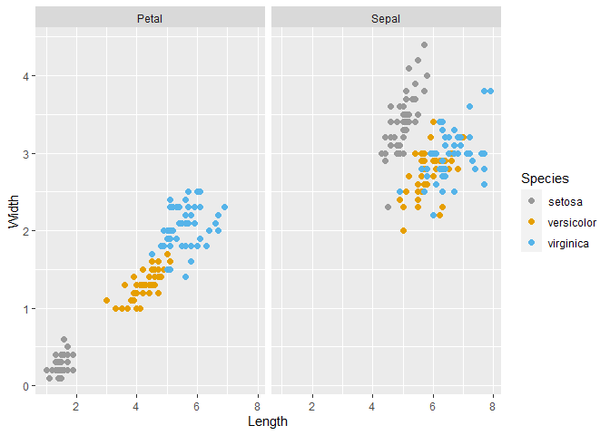

```r
#head(cleanedIris)

# Data preparation for data visualization
newiris <- cleanedIris
sepalgroup <- newiris %>% select(Sepal.Length,Sepal.Width,Species) %>%
  rename(Length=Sepal.Length,Width=Sepal.Width) %>%
  mutate(Part="Sepal")
petalgroup <- newiris %>% select(Petal.Length,Petal.Width,Species) %>%
  rename(Length=Petal.Length,Width=Petal.Width) %>%
  mutate(Part="Petal")
irisgroups <- rbind(sepalgroup,petalgroup)

# color-blind friendly palettes
# The palette with grey:
cbp1 <- c("#999999", "#E69F00", "#56B4E9", "#009E73",
          "#F0E442", "#0072B2", "#D55E00", "#CC79A7")

# The palette with black:
cbp2 <- c("#000000", "#E69F00", "#56B4E9", "#009E73",
          "#F0E442", "#0072B2", "#D55E00", "#CC79A7")

# Data visualization of Iris dataset
irisplot <- ggplot(data=irisgroups,mapping=aes(x=Length,y=Width,color=Species))+
  geom_point(size=2)+facet_wrap(~Part,ncol=2)+ scale_colour_manual(values=cbp1)
irisplot
```

# 7 Data visualization plot 2 (BEFORE ANALYSIS)

For the second plot, i used Principal Component Analysis (PCA) to extract the first 2 principal components (PC1&PC2) and plot a 2D plot, grouped by the species type of the flower, for easy visualization of data.

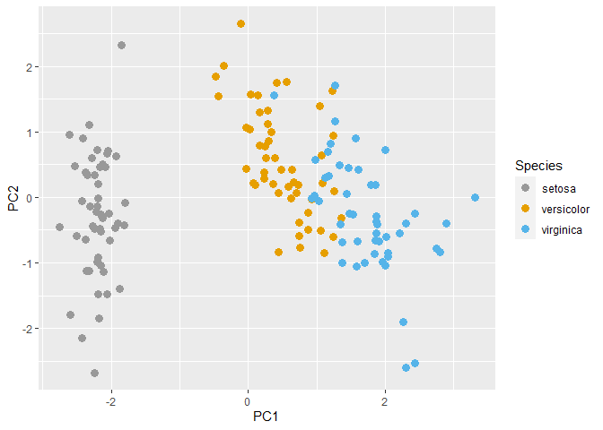

```r
# with PCA (Extract first 2 principal component)

iris_vars <- cleanedIris %>% select(!Species)
iris_matrix <- as.matrix(iris_vars)

pc <- prcomp(iris_matrix,center=TRUE,scale=TRUE,rank=2)
rotationmatrix <- pc$rotation
data_PCA <- as.data.frame(pc$x)
data_PCA$Species <- cleanedIris$Species


irisplot_PCA <- ggplot(data= data_PCA,mapping=aes(x=PC1,y=PC2,color=Species))+
              geom_point(size=3)+scale_colour_manual(values=cbp1)

irisplot_PCA
```

# 8 Key in the records of the new iris flower here

Any newly measured attributes of an iris plant are to be input under the block of code here, in the following sequence: Sepal.Length, Sepal.Width, Petal.Length, Petal.Width. Change the values in the vector.

```r
input <- c(4,3.5,1,0.5) # For this example: Sepal.Length = 4, Sepal.Width = 3.5, Petal.Length = 1, Petal.Width = 0.5
```

# 9 Using Euclidean distance as a form of similarity measure

In order to retrieve records of the ten most similar data points in the existing Iris data to the input arguments, I have used one of the most common similarity measures, which is through the use of euclidean distance. I will first combine the input argument with the existing Iris data, then i will calculate the euclidean distances between every 2 data points, storing all the results in a n by n matrix, where n = (number of data points in the iris data set + input data) Thereafter i will extract the nth row (which consists of the euclidean distance of the input data from each of the existing data point), and sort it in ascending order. The “nearest10_euclidDist” function will return the indexes of the 10 most similar data points from the iris dataset.

```r
# A function that returns the index of the 10 most similar flowers to the new iris flower measured

nearest10_euclidDist <- function(dataset,input){
  dataset_temp <- subset(dataset,select = -c(Species)) # remove the Species column from iris dataset
  dataset_temp <- rbind(dataset_temp,input) # add the new input into the (iris) dataset
  numrows <- nrow(dataset_temp) # position of the new input data
  euclidDist_matrix <- as.matrix(dist(dataset_temp[, 1:4],    # returns the euclidian matrix; n by n
                              method = "euclidean",
                              upper = TRUE,
                              diag = TRUE))
  numrows <- nrow(euclidDist_matrix) # position of the input iris flower
  euclidDist_ptOfInterest <- euclidDist_matrix[numrows,] # i am interested in this flower, which are the 10 most similar flowers?
  #print(euclidDist_ptOfInterest)
  indexes <- order(euclidDist_ptOfInterest, decreasing = FALSE) # order them by ASC order, index (smaller dist, more similar)
  indexes <- indexes[!indexes %in% c(numrows)] # exclude the point of interest (input data)
  first10_indexes <- indexes[1:10] # retrieve the first 10 most similar flower (highest cos similarity)
  first10_indexes
}

nearest10_euclidDist(cleanedIris,input) # returns the indexes of the top ten data points similar to the input data
```

```
##  [1] 43 23 14  7 39 48  3  9  4 30
```

```r
cleanedIris[nearest10_euclidDist(cleanedIris,input),] # To retrieve the records of the top ten data points similar to the input data
```

```
##    Sepal.Length Sepal.Width Petal.Length Petal.Width Species
## 43          4.4         3.2          1.3         0.2  setosa
## 23          4.6         3.6          1.0         0.2  setosa
## 14          4.3         3.0          1.1         0.1  setosa
## 7           4.6         3.4          1.4         0.3  setosa
## 39          4.4         3.0          1.3         0.2  setosa
## 48          4.6         3.2          1.4         0.2  setosa
## 3           4.7         3.2          1.3         0.2  setosa
## 9           4.4         2.9          1.4         0.2  setosa
## 4           4.6         3.1          1.5         0.2  setosa
## 30          4.7         3.2          1.6         0.2  setosa
```

# 10 Test “nearest10_euclidDist” function

For testing, i have used a dummy input of c(5,3.4,1.5,0.2), which has the same set of attributes as the flower in index 8 of the iris dataset. The “nearest10_euclidDist” function does indeed return index 8 as the most similar flower to the input.

```r
#view(iris)
# I have set same attributes to flower with index 8 as input for testing
input_test <- c(5,3.4,1.5,0.2) # input can be in vector form; Sepal.Length, Sepal.Width, Petal.Length, Petal.Width
nearest10_euclidDist(cleanedIris,input_test) # returns index 8 as the first output
```

```
##  [1]  8 40 50  1 18 27  5 12 28 29
```

```r
cleanedIris[nearest10_euclidDist(cleanedIris,input_test),]
```

```
##    Sepal.Length Sepal.Width Petal.Length Petal.Width Species
## 8           5.0         3.4          1.5         0.2  setosa
## 40          5.1         3.4          1.5         0.2  setosa
## 50          5.0         3.3          1.4         0.2  setosa
## 1           5.1         3.5          1.4         0.2  setosa
## 18          5.1         3.5          1.4         0.3  setosa
## 27          5.0         3.4          1.6         0.4  setosa
## 5           5.0         3.6          1.4         0.2  setosa
## 12          4.8         3.4          1.6         0.2  setosa
## 28          5.2         3.5          1.5         0.2  setosa
## 29          5.2         3.4          1.4         0.2  setosa
```

# 11 Data preparation for visualization (AFTER analysis)

For visualizing the results, i have created a total of 4 different types of plots. Before creating the plots, i have first prepared the data for visualization. This includes labeling the input data as “input” under the Species column in iris data set, and creating a new column called “Similar” which takes a character of either “Yes”, “No” and “Input”. “Yes” indicates that the a particular data point is within the top ten data points similar to the input data.

```r
# Data preparation for visualization
mostSimilar_10 <- nearest10_euclidDist(cleanedIris,input) # returns most 10 similar flower, indexes
newiris1 <- cleanedIris[,1:4] #exclude Species column
Species <- c(as.character(cleanedIris$Species),"Input") # convert to character, otherwise species becomes number 1,2,3
Species <- as.factor(Species) # convert back to factor
newiris1 <- rbind(newiris1,input)##
newiris1 <- cbind(newiris1,Species)
numrows <- nrow(newiris1) # index of new input
newiris1$Similar <- "No"
newiris1$Similar[mostSimilar_10] <- "Yes"
newiris1$Similar[numrows] <- "Input"
```

# 12 Data visualization plot 1 (AFTER analysis)

For the first plot, i have created a plot that visualizes all 4 feature variables (Sepal.Length, Sepal.Width, Petal.Length, Petal.Width) of the flower. This plot includes all the data points in the Iris data set and the input data point. The grey dot represents the input data; The blue dots represents the top ten data points similar to the input data; The orange dots represents the remaining data points.

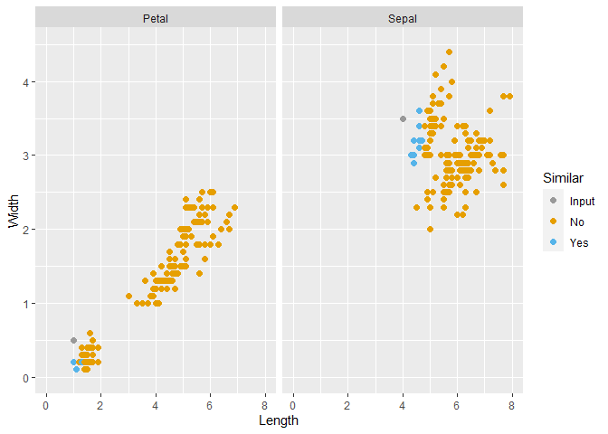

```r
# Plot number 1
sepalgroup1 <- newiris1 %>% select(Sepal.Length,Sepal.Width,Species,Similar) %>%
  rename(Length=Sepal.Length,Width=Sepal.Width) %>%
  mutate(Part="Sepal")
petalgroup1 <- newiris1 %>% select(Petal.Length,Petal.Width,Species,Similar) %>%
  rename(Length=Petal.Length,Width=Petal.Width) %>%
  mutate(Part="Petal")
irisgroups1 <- rbind(sepalgroup1,petalgroup1)

irisplot1 <- ggplot(data=irisgroups1,mapping=aes(x=Length,y=Width,color=Similar))+
  geom_point(size=2)+facet_wrap(~Part,ncol=2)+ scale_colour_manual(values=cbp1) + xlim(0,8) + ylim(0,4.5)

irisplot1
```

# 13 Data visualization plot 2 (AFTER analysis)

The second plot is similar to plot number one, but excluding the points that are not within the top ten data points similar to the input data. The grey dot represents the input data;The orange dot represents the top ten data points similar to the input data.

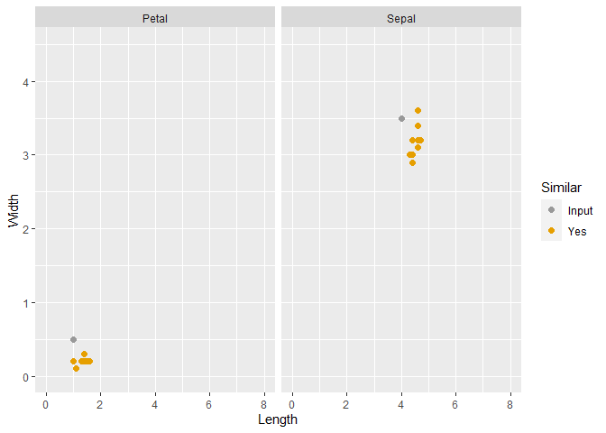

```r
# Plot number 2
newiris2 <- subset(newiris1,Similar != "No")
sepalgroup2 <- newiris2 %>% select(Sepal.Length,Sepal.Width,Species,Similar) %>%
  rename(Length=Sepal.Length,Width=Sepal.Width) %>%
  mutate(Part="Sepal")
petalgroup2 <- newiris2 %>% select(Petal.Length,Petal.Width,Species,Similar) %>%
  rename(Length=Petal.Length,Width=Petal.Width) %>%
  mutate(Part="Petal")
irisgroups2 <- rbind(sepalgroup2,petalgroup2)

irisplot2 <- ggplot(data=irisgroups2,mapping=aes(x=Length,y=Width,color=Similar))+
  geom_point(size=2)+facet_wrap(~Part,ncol=2)+ scale_colour_manual(values=cbp1) + xlim(0,8) + ylim(0,4.5)

irisplot2
```

# 14 Data visualization plot 3 (AFTER analysis)

For the third plot, i have created a plot that visualizes all 4 feature variables (Sepal.Length, Sepal.Width, Petal.Length, Petal.Width) of the flower. This plot includes all the data points in the iris data set(including the input data point), grouped by the species type of the flower.  
The grey dot represents the input data; The orange dots represents the Setosa Type; The blue dots represents the Versicolor Type; The green dots represents the Virginica Type. Those datapoints marked with a black inner dot represents the top ten data points similar to the input data.

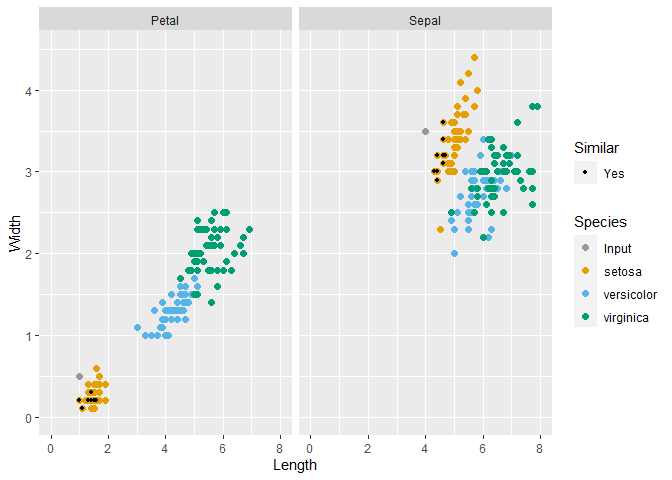

```r
# Plot number 3
irisplot3 <- ggplot(data=irisgroups1,mapping=aes(x=Length,y=Width,color=Species))+
geom_point(size=2)+facet_wrap(~Part,ncol=2)+ scale_colour_manual(values=cbp1)+
geom_point(data=irisgroups1[irisgroups1$Similar == "Yes",],
mapping=aes(x=Length,y=Width,fill=Similar),color="black",shape = "circle",size=1)+
xlim(0,8) + ylim(0,4.5)

irisplot3
```

# 15 Data visualization plot 4 (AFTER analysis)

The fourth plot is similar to plot number three, but for the fourth plot, I have used Principal Component Analysis (PCA) to extract the first 2 principal components (PC1&PC2) before plotting a 2D plot, grouped by Species Type. The grey dot represents the input data; The orange dots represents the Setosa Type; The blue dots represents the Versicolor Type; The green dots represents the Virginica Type. Those data points marked with a black inner dot represents the top ten data points similar to the input data.

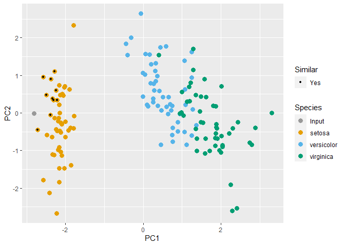

```r
# Plot number 4 (PCA plot, extract first 2 pricipal components)

# data prep using PCA
iris_vars <- cleanedIris %>% select(!Species)
iris_vars <- rbind(iris_vars,input)
iris_matrix <- as.matrix(iris_vars)

pc <- prcomp(iris_matrix,center=TRUE,scale=TRUE,rank=2)
rotationmatrix <- pc$rotation
data_PCA <- as.data.frame(pc$x)
Species <- c(as.character(cleanedIris$Species),"Input") # convert to character, otherwise species becomes number 1,2,3
Species <- as.factor(Species) # convert back to factor
data_PCA$Species <- Species
numrows <- nrow(iris_matrix) # index of new input
data_PCA$Similar <- "No"
data_PCA$Similar[mostSimilar_10] <- "Yes"
data_PCA$Similar[numrows] <- "Input"

# plot 4
irisplot4 <- ggplot(data= data_PCA,mapping=aes(x=PC1,y=PC2,color=Species))+
              geom_point(size=3)+scale_colour_manual(values=cbp1)+geom_point(data=data_PCA[data_PCA$Similar == "Yes",],
mapping=aes(x=PC1,y=PC2,fill=Similar),color="black",shape = "circle",size=1)

irisplot4
```

# 16 Combination of all the graphs for data visualization

```r
irisplot1
irisplot2
irisplot3
irisplot4
```

[output not shown]

# 17 (ADDITIONAL) END OF ANALYSIS; Using Cosine similairity as a form of similarity measure

I have also also tried using Cosine Similarity as a form of similarity measure but ultimately chosen to go with euclidean distance as the measure to be used for this test.

```r
# Besides using euclidean distance as a form of similarity measure, i have also tried using cosine similarity

cosineSim <- function(dataset,input){
  dataset <- subset(dataset,select = -c(Species)) # remove the Species column from iris dataset, causing some NA issue
  dataset <- rbind(dataset,input) # add the new input into the (iris) dataset
  numrows <- nrow(dataset)
  cosineSimMatrix <- matrix(0,numrows,numrows) # create a zero matrix for storing cosine sim value; dim should be n by n; n = num obs in dataset
  #print(dim(cosineSimMatrix))
  for (row in 1:numrows){
    for (col in 1:numrows){
      #print(row)
      #print(col)
      firstVec <- as.numeric(dataset[row,1:4]) # 1 row of dataset
      #print(firstVec)
      secondVec <- as.numeric(dataset[col,1:4]) # another row of dataset with comparison to the firstVec
      #print(secondVec)
      cos_theta <- dot(firstVec,secondVec)/(sqrt(dot(firstVec,firstVec))*sqrt(dot(secondVec,secondVec))) # cos sim measure
      cosineSimMatrix[row,col] <- cos_theta # store in the matrix created earlier
}
  }
  cosineSimMatrix
}

#input <- c(5,3.4,1.5,0.2)
#matrix_cosSim <- cosineSim(cleanedIris,input)

nearest10_cosSim <- function(dataset,input){
  cosineSim_matrix <- cosineSim(dataset,input) # returns the cos sim matrix; n by n
  numrows <- nrow(cosineSim_matrix) # position of the input iris flower
  cosineSim_ptOfInterest <- cosineSim_matrix[numrows,] # i am interested in this flower, which are the 10 most similar flowers?
  #print(cosineSim_ptOfInterest)
  indexes <- order(cosineSim_ptOfInterest, decreasing = TRUE) # order them by descending order, index
  #print(indexes)
  indexes <- indexes[!indexes %in% c(numrows)] # exclude the point of interest (input data)
  #print(indexes)
  first10_indexes <- indexes[1:10] # retrieve the first 10 most similar flower (highest cos similarity)
  first10_indexes
}

# test
# similar attributes to flower 8
input <- c(5,3.4,1.5,0.2) # input can be in vector form; Sepal.Length, Sepal.Width, Petal.Length, Petal.Width
nearest10_cosSim(cleanedIris,input)
```

[output not shown]

# 18 (ADDITIONAL) END OF ANALYSIS; Comparing Cosine Similarity & Euclidean distance similarity measure

```r
# test
# similar attributess to flower 8
input_test <- c(5,3.4,1.5,0.2) # input can be in vector form; Sepal.Length, Sepal.Width, Petal.Length, Petal.Width
nearest10_cosSim(cleanedIris,input_test)
nearest10_euclidDist(cleanedIris,input_test)
```

[output not shown]

# 19 Sources

```r
# https://www.datanovia.com/en/blog/ggplot-colors-best-tricks-you-will-love/#change-colors-by-groups-ggplot-default-colors
# https://jfly.uni-koeln.de/color/
#https://www.itpro.co.uk/business-intelligence-bi/29773/how-to-measure-data-quality
```